# An Introduction to Apache Spark and SparkR

Jared Harpole

August 6, 2016

# Overview

- What is Hadoop?
- What is Mapreduce?
- What is Apache Spark?
- Quick Tutorial of SparkR

# What is Hadoop?

- An open-source software framework for distributed storeage and distributed processing on clusters.
- Created by Doug Cutting in 2006 based on a 2004 paper from Google.
- Solves the problem of storing and processing massive amounts of data.
  - Relational database servers such as SQL break down with Terabytes and Petabytes

# What is Hadoop Cont?

- Breaks massive data sets up into indpendent chunks and operate on each chunk
  - Count the number of words in 10 billion news articles
  - Process Tweets from Twitter and analyze the data
  - Process and compute statistics on location records of mobile phone subscribers
- Hadoop is written in Java and uses a framework called Mapreduce to process the massive amounts of data.

# What is Mapreduce?

- A distributed computing framework based on work of Jeffrey Dean and Sanjay Ghemawat from Google in 2004.
- Idea is to utilize a large number of machines to process certain jobs in parallel using mappers and reducers.
- A core idea of Mapreduce are thinking and operating in (key, value) pairs
  - (with, 1), (the, 1), (the, 1), (you, 2)
  - (Jared Harpole, [23, PSYC101, A]), (Steve Simon, [45, MATH115, A])
- Input of a mapreduce program is a set of (key, value) pairs

# Visual of Mapreduce

- An Image of Hadoop and Mapreduce: http://www.milanor.net/blog/an-example-of-mapreduce-with-rmr2/

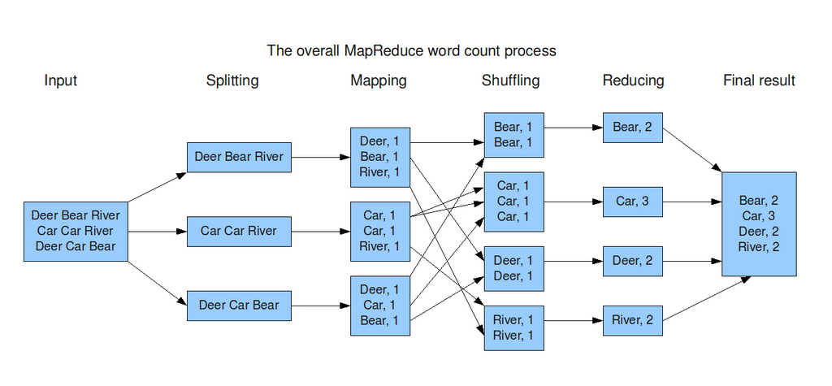

# Let’s Look at the Code: Mapper

- The input to the mapper is a word. Will emit (word, 1) for word count

```r
#! /usr/bin/env Rscript

input <- file('stdin', 'r')

while(length(line <- readLines(input, n = 1, warn = FALSE)) > 0){
  if(nchar(line) == 0) break

  fields <- unlist(strsplit(line, '\n'))
  cat(fields[1], '\t', '1', '\n')
}

close(input)
```

# Let’s Look at the Code: Reducer

- Remember the Mapper emits (word, 1)

```r
#! /usr/bin/env Rscript

con <- file('stdin', 'r')
is_first_line <- TRUE
while(length(line <- readLines(con, n = 1, warn = FALSE)) > 0) {
  pieces <- unlist(strsplit(line, '\t'))
  if(!is_first_line && prev_word == pieces[1]){
    sum <- sum + as.integer(pieces[2])
  } else {

    if(!is_first_line){
      cat(prev_word, "\t", sum, "\n")
    }
    prev_word <- pieces[1]
    sum <- as.integer(pieces[2])
    is_first_line <- FALSE
  }
}
cat(prev_word, "\t", sum, "\n")
close(con)
```

# Let’s Show How they Work: Part 1

```
cat /home/jared/sparkR_pres/words.txt
```

```
happy
sad
glad
sad
glad
yet
do
happy
motivate
summer
spring
sad
fall
summer
spring
happy
glad
```

# Let’s Show How they Work: Part 2

```
cat ./words.txt | Rscript ./mapper.R
```

```
happy    1
sad      1
glad     1
sad      1
glad     1
yet      1
do   1
happy    1
motivate     1
summer   1
spring   1
sad      1
fall     1
summer   1
spring   1
happy    1
glad     1
```

# Let’s Show How they Work: Part 3

```
cat ./words.txt | Rscript ./mapper.R | sort -k1,1 | Rscript ./reducer.R
```

```
do       1
fall     1
glad     3
happy    3
motivate     1
sad      3
spring       2
summer       2
yet      1
```

# Hadoop and Mapreduce Recap

- Hadoop and Mapreduce are good for the following:
  - Processing terabytes and petabytes of data using batch processing
  - Storing diverse data
  - Parallel processing 1 by 1 (i.e. Sums and Aggregates)
- Hadoop and Mapreduce are not good for the following:
  - Real time data processing and/or analytics
  - RDS system (very slow) Hive can help for non-time sensitive queries
  - Quick programming for data manipulation/munging and analytics

# What is Apache Spark?

- Very fast cluster computing framework for fast computations
- Extends the Mapreduce framework for use with interactive queries, streaming, and iterative processing (Machine Learning algorithms)
- Some report up to 100 times faster than Mapreduce
- Much easier to program in as a data scientist and/or data analyst

# What is Apache Spark Cont..?

- Has excellent features
  - Supports multiple languages (i.e. Java, Scala, Python, R)
  - Advanced Analytics
  - Speed
- Components
  - Spark SQL
  - Spark Streaming
  - ML/MLlib
  - GraphX

# What is Apache Spark Cont…?

- Core structure in Spark is the resilient distributed datasets (RDD)
- Read only partitioned collection of records
- RDDs are what store the data across the cluster.
- Think of it as a faster way for Mapreduce to happen due to in memory processing and fast retrieval.

# Motivating Example of Apache Spark

- Remember the word count with our mapper.R and reducer.R
  - Approximately 31 lines of code
- Here is the equivalent sparkR implementation:

```r
library(magrittr)
library(SparkR)

sc <- sparkR.init(master = "local")
```

```
Launching java with command  java   -Xmx512m -cp '/home/jared/R/x86_64-pc-linux-gnu-library/3.3/SparkR/sparkr-assembly-0.1.jar:' edu.berkeley.cs.amplab.sparkr.SparkRBackend /tmp/RtmpB4GnZo/backend_port4fdd713d194a
```

```r
wordCount <- sc %>%
  textFile("./words.txt") %>%
  map(function(x) {
    tmp <- unlist(strsplit(x, '\n'))
    return(list(tmp, 1))
    }) %>% reduceByKey(`+`, 2L)
wordCount %>% collect()
```

```
[[1]]
[[1]][[1]]
[1] "sad"

[[1]][[2]]
[1] 3


[[2]]
[[2]][[1]]
[1] "yet"

[[2]][[2]]
[1] 1


[[3]]
[[3]][[1]]
[1] "glad"

[[3]][[2]]
[1] 3


[[4]]
[[4]][[1]]
[1] "happy"

[[4]][[2]]
[1] 3


[[5]]
[[5]][[1]]
[1] "motivate"

[[5]][[2]]
[1] 1


```

[output cut: 15 more lines]

```

[[8]]
[[8]][[1]]
[1] "summer"

[[8]][[2]]
[1] 2


[[9]]
[[9]][[1]]
[1] "spring"

[[9]][[2]]
[1] 2
```

# Quickstart for SparkR

- Install devtools and magrittr R packages

```r
install.packages(c("devtools", "magrittr"))
```

- Load devtools and magrittr and run the following install_github command

```r
library(devtools)
library(magrittr)

install_github("amplab-extras/SparkR-pkg",subdir = "pkg")
```

- This is a bare bones install that is quick and easy to do and for me to explain
- A better way would be to download the .tgz file from Apache Spark and follow the directions on installing SparkR.

# Some Quick Book Keeping Items

- When using Spark we are dealing with RDDs that are distributed on a cluster.
- In Spark you have something called a Driver
  - The driver is the master node and can store objects in memory.
  - The workers are on the cluster
  - Given that we are operating in local mode you may be like why does this matter
- When running Spark for real on real world problems you will likely be on a cluster.

# Spark Functions with SparkR: parallelize, first, take, collect, and count

- parallelize creates an RDD and is often useful for tutorials like this or quick prototyping or testing

```r
library(magrittr)
library(SparkR)
sc <- sparkR.init(master = "local")
```

```
Launching java with command  java   -Xmx512m -cp '/home/jared/R/x86_64-pc-linux-gnu-library/3.3/SparkR/sparkr-assembly-0.1.jar:' edu.berkeley.cs.amplab.sparkr.SparkRBackend /tmp/RtmpWWmAQf/backend_port5a444ea5bcfb
```

```r
tmpRDD <- sc %>% parallelize(c(1, 2, 3, 4, 5, 6))
tmpRDD
```

```
An object of class "RDD"
Slot "env":
<environment: 0x34c6578>

Slot "jrdd":
Java ref type org.apache.spark.api.java.JavaRDD id 1
```

- When operating on an RDD your typical r functions like head and tail won’t work
- Instead we need to use first, take, or collect

```r
library(magrittr)
library(SparkR)
sc <- sparkR.init(master = "local")
```

```
Re-using existing Spark Context. Please stop SparkR with sparkR.stop() or restart R to create a new Spark Context
```

```r
tmpRDD <- sc %>% parallelize(c(1, 2, 3, 4, 5, 6))

tmpRDD %>% first
```

```
[1] 1
```

```r
tmpRDD %>% take(3)
```

```
[[1]]
[1] 1

[[2]]
[1] 2

[[3]]
[1] 3
```

```r
tmpRDD %>% collect()
```

```
[[1]]
[1] 1

[[2]]
[1] 2

[[3]]
[1] 3

[[4]]
[1] 4

[[5]]
[1] 5

[[6]]
[1] 6
```

```r
tmpRDD %>% count()
```

```
[1] 6
```

# Spark Functions with SparkR: filter

- Simple Filters

```r
library(magrittr)
library(SparkR)
sc <- sparkR.init(master = "local")
```

```
Re-using existing Spark Context. Please stop SparkR with sparkR.stop() or restart R to create a new Spark Context
```

```r
myfirstRDD <- sc %>%
  parallelize(sample(1:100, 40, replace = TRUE))

## filterRDD function
myfirstRDD_filtered <- myfirstRDD %>%
  filterRDD(function(x) x > 30)

myfirstRDD_filtered %>% count()
```

```
[1] 32
```

```r
myfirstRDD_filtered %>% take(10)
```

```
[[1]]
[1] 75

[[2]]
[1] 72

[[3]]
[1] 33

[[4]]
[1] 72

[[5]]
[1] 69

[[6]]
[1] 81

[[7]]
[1] 44

[[8]]
[1] 44

[[9]]
[1] 59

[[10]]
[1] 56
```

```r
## Can chain operations
myfirstRDD %>%
  filterRDD(function(x) x > 30) %>%
  take(10)
```

```
[[1]]
[1] 75

[[2]]
[1] 72

[[3]]
[1] 33

[[4]]
[1] 72

[[5]]
[1] 69

[[6]]
[1] 81

[[7]]
[1] 44

[[8]]
[1] 44

[[9]]
[1] 59

[[10]]
[1] 56
```

- Slightly more complicated filter

```r
library(magrittr)
library(SparkR)
sc <- sparkR.init(master = "local")
```

```
Re-using existing Spark Context. Please stop SparkR with sparkR.stop() or restart R to create a new Spark Context
```

```r
myfirstRDD <- sc %>%
  parallelize(list(list("a", 1), list("b", 2), list("c", 1), list("d", 3)))

myfirstRDD %>%
  filterRDD(function(x) x[2] > 1) %>%
  take(2)
```

```
[[1]]
[[1]][[1]]
[1] "b"

[[1]][[2]]
[1] 2


[[2]]
[[2]][[1]]
[1] "d"

[[2]][[2]]
[1] 3
```